P— title: “GARCH Model” author: “Jane” date: “19/04/2021” output: html_document —

# Forcasting Exchange Rate Using GARCH Model

## Reading Canadian and Japanes Currency into r

```r
library(readr)
library(dplyr)
CanJapCurrency <- readxl::read_xlsx ("CADJPY_Candlestick_1_D_BID_01.01.2000-31.12.2020.xlsx")%>%
  select('Gmt time', Close)%>%
  rename(Date = ('Gmt time'), Rate = ("Close"))

head(CanJapCurrency)
```

```
## # A tibble: 6 x 2
##   Date                 Rate
##   <dttm>              <dbl>
## 1 2000-01-03 00:00:00  70.1
## 2 2000-01-04 00:00:00  71.0
## 3 2000-01-05 00:00:00  71.9
## 4 2000-01-06 00:00:00  72.1
## 5 2000-01-07 00:00:00  72.3
## 6 2000-01-10 00:00:00  72.2
```

## Conversion of Gmt time to date format

```r
library(dplyr)
library(lubridate)
CanJapCurrency$Date <- lubridate::ymd(CanJapCurrency$Date)
head(CanJapCurrency)
```

```
## # A tibble: 6 x 2
##   Date        Rate
##   <date>     <dbl>
## 1 2000-01-03  70.1
## 2 2000-01-04  71.0
## 3 2000-01-05  71.9
## 4 2000-01-06  72.1
## 5 2000-01-07  72.3
## 6 2000-01-10  72.2
```

##Checking for obvious errors

```r
#Checking for obvious errors
which(is.na(CanJapCurrency))
```

```
## integer(0)
```

##Converting the data set into time series object

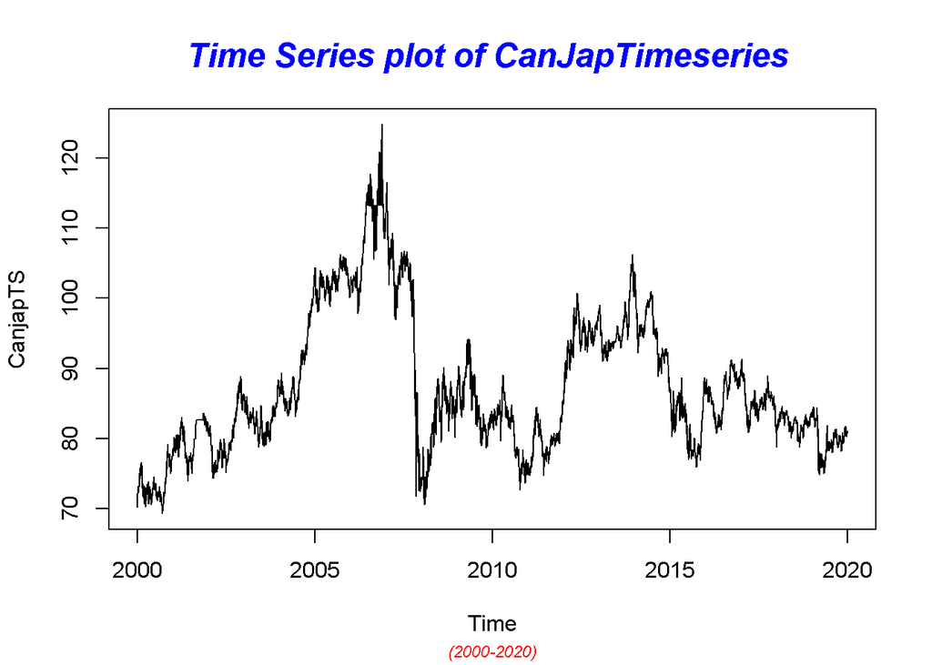

```r
#Converting the data set into time series object
CanjapTS<- ts(as.vector(CanJapCurrency$Rate),  frequency = 314, start= c(2000,01,03))
plot.ts(CanjapTS)
title("Time Series plot of CanJapTimeseries ", sub = "(2000-2020)",
      cex.main = 1.5,   font.main= 4, col.main= "blue",
      cex.sub = 0.75, font.sub = 3, col.sub = "red")
```

## Automatic Colleration and Partial Automatic Correlation

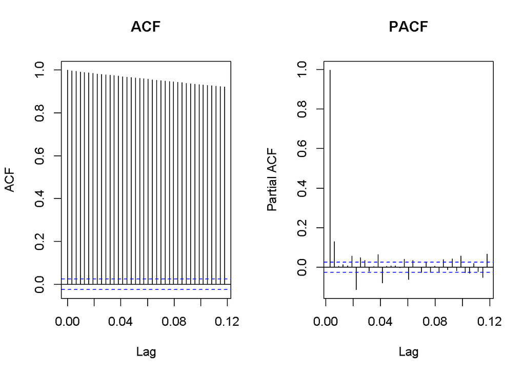

```r
par(mfrow=c(1,2))
acf(CanjapTS, main=" ACF ")
pacf(CanjapTS, main=" PACF ")
```

```r
ar(diff(CanjapTS))
```

```
##
## Call:
## ar(x = diff(CanjapTS))
##
## Coefficients:
##       1        2        3        4        5        6        7        8
## -0.1050  -0.0022  -0.0262  -0.0164  -0.0254   0.0935  -0.0483  -0.0362
##       9       10       11       12       13       14       15       16
##  0.0160  -0.0126  -0.0598   0.0786  -0.0043  -0.0108  -0.0065   0.0052
##      17       18       19       20       21       22       23       24
## -0.0495   0.0742  -0.0490   0.0074   0.0255  -0.0205   0.0139   0.0095
##      25       26       27       28       29       30       31       32
##  0.0105  -0.0417   0.0080  -0.0493   0.0026  -0.0502   0.0298   0.0324
##      33       34       35       36       37
## -0.0177   0.0289   0.0483  -0.0736   0.0208
##
## Order selected 37  sigma^2 estimated as  0.5129
```

##Augmented Dickey-Fuller test ##The Augmented Dickey-Fuller test allows for higher-order autoregressive processes

```r
library(tseries)
adf.test(CanjapTS, alternative = "stationary", k = 0)
```

```
##
##  Augmented Dickey-Fuller Test
##
## data:  CanjapTS
## Dickey-Fuller = -3.2006, Lag order = 0, p-value = 0.08772
## alternative hypothesis: stationary
```

##Ensuring the stationarity of the series: ##Transformation:Natural Logarithmic transformation is one of the best approach to look for stationarity of the sereis.

```r
CanJapLogTran<-log(CanjapTS)

ar(CanJapLogTran)
```

```
##
## Call:
## ar(x = CanJapLogTran)
##
## Coefficients:
##       1        2        3        4        5        6        7        8
##  0.9195   0.0786  -0.0314   0.0194  -0.0011   0.0573  -0.0822   0.0122
##       9       10       11       12       13       14       15       16
##  0.0393  -0.0182  -0.0447   0.1031  -0.0630   0.0027  -0.0046   0.0176
##      17       18       19       20       21       22       23       24
## -0.0417   0.0921  -0.0989   0.0449   0.0175  -0.0418   0.0334   0.0028
##      25       26       27       28       29       30       31       32
## -0.0060  -0.0493   0.0484  -0.0538   0.0451  -0.0262   0.0505   0.0030
##      33       34       35       36       37
## -0.0459   0.0421   0.0167  -0.0874   0.0478
##
## Order selected 37  sigma^2 estimated as  7.202e-05
```

## Augmented Dickey-Fuller Test for log Tranformation

```r
adf.test(CanJapLogTran, alternative = "stationary", k = 0)
```

```
##
##  Augmented Dickey-Fuller Test
##
## data:  CanJapLogTran
## Dickey-Fuller = -3.2236, Lag order = 0, p-value = 0.08377
## alternative hypothesis: stationary
```

## ACF and PACF for log transformation

## The ACF and PACF plot are similar to the original series and we can still suspect the non-stationarity of the series and this is also supported by Unit root test.

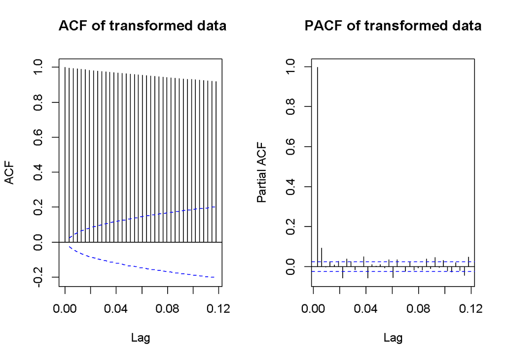

```r
par(mfrow=c(1,2))
acf(CanJapLogTran, ci.type='ma', main=" ACF of transformed data")

pacf(CanJapLogTran,  main="PACF of transformed data")
```

##Differencing as my next approach to achieve the stationarity of the series.

```r
DiffCanJapLogTran<-diff(CanJapLogTran)
ar(DiffCanJapLogTran)
```

```
##
## Call:
## ar(x = DiffCanJapLogTran)
##
## Coefficients:
##       1        2        3        4        5        6        7        8
## -0.0801   0.0044  -0.0338  -0.0129  -0.0138   0.0519  -0.0412  -0.0282
##       9       10       11       12       13       14       15       16
##  0.0150  -0.0104  -0.0506   0.0572  -0.0089  -0.0067  -0.0089   0.0098
##      17       18       19       20       21       22       23       24
## -0.0412   0.0625  -0.0435   0.0039   0.0246  -0.0187   0.0120   0.0121
##      25       26       27       28       29       30       31       32
##  0.0125  -0.0393   0.0042  -0.0523  -0.0043  -0.0307   0.0254   0.0331
##      33       34       35       36       37
## -0.0166   0.0262   0.0436  -0.0562   0.0215
##
## Order selected 37  sigma^2 estimated as  6.393e-05
```

## Runing ACF and PACF for the log transform Difference

##At the first difference of the transformed series, we can observe the plots of ACF and PACF shows a bit difference to the previous steep decreasing pattern. As we can ensure the assumption of stationarity with Unit-Root test.

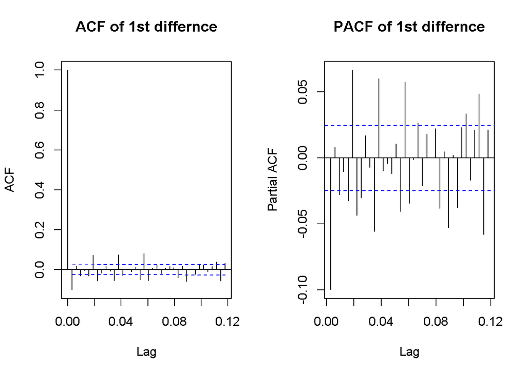

```r
par(mfrow=c(1,2))
acf(DiffCanJapLogTran, ci.type='ma', main="ACF of 1st differnce")
pacf(DiffCanJapLogTran, main="PACF of 1st differnce")
```

## Augmented Dickey-Fuller Test for log Tranformation Difference

```r
adf.test(DiffCanJapLogTran, alternative = "stationary", k = 0)
```

```
##
##  Augmented Dickey-Fuller Test
##
## data:  DiffCanJapLogTran
## Dickey-Fuller = -87.573, Lag order = 0, p-value = 0.01
## alternative hypothesis: stationary
```

### With reference to the Dickey-Fuller Test, p-value is less than the 0.02 and we can reject the null hypothesis stating the non-stationarity. Hence , we can proceed further for model selection .

#MODEL ESTIMATION: ##GARCH (2,1): for Canadian and Japanese Curruency Pair

```r
# GARCH(2,1)
CanJapGARCHFit.21 = garch(DiffCanJapLogTran,order=c(2,1),trace =FALSE)
summary(CanJapGARCHFit.21)
```

```
##
## Call:
## garch(x = DiffCanJapLogTran, order = c(2, 1), trace = FALSE)
##
## Model:
## GARCH(2,1)
##
## Residuals:
##      Min       1Q   Median       3Q      Max
## -5.82350 -0.53716  0.01713  0.57391  6.00789
##
## Coefficient(s):
##     Estimate  Std. Error  t value Pr(>|t|)
## a0 7.028e-07          NA       NA       NA
## a1 8.534e-02          NA       NA       NA
## b1 5.063e-01          NA       NA       NA
## b2 3.968e-01          NA       NA       NA
##
## Diagnostic Tests:
##  Jarque Bera Test
##
## data:  Residuals
## X-squared = 806.92, df = 2, p-value < 2.2e-16
##
##
##  Box-Ljung test
##
## data:  Squared.Residuals
## X-squared = 0.10902, df = 1, p-value = 0.7413
```

## GARCH (2,2):

##This model can be interpreted as an overfit model of GARCH(2,1) and p values from residual tests confirms that residuals are highly correlated. Thus this model is not consider to be a good fit.

```r
CanJapGARCHFit.22 = garch(DiffCanJapLogTran, order =c(2,2),trace =FALSE)
summary(CanJapGARCHFit.22)
```

```
##
## Call:
## garch(x = DiffCanJapLogTran, order = c(2, 2), trace = FALSE)
##
## Model:
## GARCH(2,2)
##
## Residuals:
##      Min       1Q   Median       3Q      Max
## -6.02302 -0.51052  0.01635  0.54297  7.20419
##
## Coefficient(s):
##     Estimate  Std. Error  t value Pr(>|t|)
## a0 1.753e-06          NA       NA       NA
## a1 2.094e-01          NA       NA       NA
## a2 3.491e-14          NA       NA       NA
## b1 3.809e-01          NA       NA       NA
## b2 4.093e-01          NA       NA       NA
##
## Diagnostic Tests:
##  Jarque Bera Test
##
## data:  Residuals
## X-squared = 1266.7, df = 2, p-value < 2.2e-16
##
##
##  Box-Ljung test
##
## data:  Squared.Residuals
## X-squared = 14.799, df = 1, p-value = 0.0001196
```

##GARCH (3,1): ##This model can be interpreted as an overfit model of GARCH(2,1) and GARCH (2,2). This model may not be consider to be a good fit.

```r
CanJapGARCHFit.31 = garch(DiffCanJapLogTran,order=c(3,1),trace =FALSE)
summary(CanJapGARCHFit.31)
```

```
##
## Call:
## garch(x = DiffCanJapLogTran, order = c(3, 1), trace = FALSE)
##
## Model:
## GARCH(3,1)
##
## Residuals:
##      Min       1Q   Median       3Q      Max
## -5.80603 -0.53899  0.01701  0.57338  5.98266
##
## Coefficient(s):
##     Estimate  Std. Error  t value Pr(>|t|)
## a0 7.562e-07          NA       NA       NA
## a1 8.936e-02          NA       NA       NA
## b1 4.135e-01          NA       NA       NA
## b2 4.843e-01          NA       NA       NA
## b3 1.937e-08          NA       NA       NA
##
## Diagnostic Tests:
##  Jarque Bera Test
##
## data:  Residuals
## X-squared = 795.22, df = 2, p-value < 2.2e-16
##
##
##  Box-Ljung test
##
## data:  Squared.Residuals
## X-squared = 0.27024, df = 1, p-value = 0.6032
```

##GARCH (3,2): ##This model can be interpreted as an overfitting model and p values from residual tests confirms that residuals are highly correlated. Thus this model is not consider to be a good fit.

# GARCH(3,2)

```r
CanJapGARCHFit.32 = garch(DiffCanJapLogTran,order=c(3,2),trace =FALSE)
summary(CanJapGARCHFit.32)
```

```
##
## Call:
## garch(x = DiffCanJapLogTran, order = c(3, 2), trace = FALSE)
##
## Model:
## GARCH(3,2)
##
## Residuals:
##      Min       1Q   Median       3Q      Max
## -6.32413 -0.52578  0.01685  0.55821  6.57841
##
## Coefficient(s):
##     Estimate  Std. Error  t value Pr(>|t|)
## a0 2.992e-06          NA       NA       NA
## a1 1.971e-01          NA       NA       NA
## a2 5.013e-02          NA       NA       NA
## b1 8.747e-07          NA       NA       NA
## b2 3.449e-01          NA       NA       NA
## b3 3.713e-01          NA       NA       NA
##
## Diagnostic Tests:
##  Jarque Bera Test
##
## data:  Residuals
## X-squared = 1099.7, df = 2, p-value < 2.2e-16
##
##
##  Box-Ljung test
##
## data:  Squared.Residuals
## X-squared = 14.666, df = 1, p-value = 0.0001284
```

## GARCH (3,3):

# GARCH(3,3)

```r
CanJapGARCHFit.33 = garch(DiffCanJapLogTran,order=c(3,3),trace =FALSE)
summary(CanJapGARCHFit.33)
```

```
##
## Call:
## garch(x = DiffCanJapLogTran, order = c(3, 3), trace = FALSE)
##
## Model:
## GARCH(3,3)
##
## Residuals:
##      Min       1Q   Median       3Q      Max
## -5.82696 -0.52750  0.01667  0.56015  6.91365
##
## Coefficient(s):
##     Estimate  Std. Error  t value Pr(>|t|)
## a0 3.235e-06          NA       NA       NA
## a1 4.831e-02          NA       NA       NA
## a2 1.112e-01          NA       NA       NA
## a3 1.469e-01          NA       NA       NA
## b1 1.219e-02          NA       NA       NA
## b2 2.550e-01          NA       NA       NA
## b3 3.950e-01          NA       NA       NA
##
## Diagnostic Tests:
##  Jarque Bera Test
##
## data:  Residuals
## X-squared = 995.93, df = 2, p-value < 2.2e-16
##
##
##  Box-Ljung test
##
## data:  Squared.Residuals
## X-squared = 1.4164, df = 1, p-value = 0.234
```

```r
CanJapGARCHFit.42 = garch(DiffCanJapLogTran,order=c(4,2),trace =FALSE)
summary(CanJapGARCHFit.42)
```

```
##
## Call:
## garch(x = DiffCanJapLogTran, order = c(4, 2), trace = FALSE)
##
## Model:
## GARCH(4,2)
##
## Residuals:
##      Min       1Q   Median       3Q      Max
## -5.90742 -0.53569  0.01732  0.56932  5.90202
##
## Coefficient(s):
##     Estimate  Std. Error  t value Pr(>|t|)
## a0 1.127e-06          NA       NA       NA
## a1 1.019e-01          NA       NA       NA
## a2 3.626e-02          NA       NA       NA
## b1 3.352e-01          NA       NA       NA
## b2 1.800e-02          NA       NA       NA
## b3 8.914e-02          NA       NA       NA
## b4 4.006e-01          NA       NA       NA
##
## Diagnostic Tests:
##  Jarque Bera Test
##
## data:  Residuals
## X-squared = 779.03, df = 2, p-value < 2.2e-16
##
##
##  Box-Ljung test
##
## data:  Squared.Residuals
## X-squared = 1.038, df = 1, p-value = 0.3083
```

#Model Selection:

##Best possible model is selected by AIC scores of the models. From the below sort function, GARCH(2,1) would be the best model for the return series.

```r
library(dLagM)
GARCHModelSelectionCanJap = AIC(CanJapGARCHFit.21,CanJapGARCHFit.22 ,CanJapGARCHFit.31,CanJapGARCHFit.32,CanJapGARCHFit.33, CanJapGARCHFit.42)
sortScore(GARCHModelSelectionCanJap, score ="aic")
```

```
##                   df       AIC
## CanJapGARCHFit.21  4 -44856.77
## CanJapGARCHFit.31  5 -44847.13
## CanJapGARCHFit.42  7 -44841.23
## CanJapGARCHFit.33  7 -44759.72
## CanJapGARCHFit.32  6 -44742.18
## CanJapGARCHFit.22  5 -44722.43
```

# Model Fitting:

```r
library(rugarch)
```

```
##
## please wait...calculating quantiles...
```

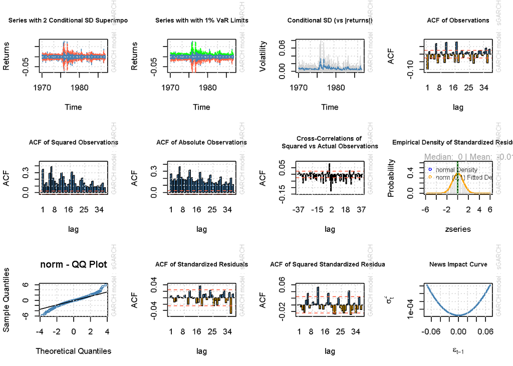

```r
CanJapmodel2.1<-ugarchspec(variance.model = list(model = "sGARCH", garchOrder = c(2, 2)),
                  mean.model = list(armaOrder = c(1, 1), include.mean = TRUE),
                  distribution.model = "norm")

MODEL2.1<-ugarchfit(spec=CanJapmodel2.1,data=DiffCanJapLogTran, out.sample = 100)
plot(MODEL2.1,which="all")
```

##Model Diagnostics

```r
MODEL2.1
```

```
##
## *---------------------------------*
## *          GARCH Model Fit        *
## *---------------------------------*
##
## Conditional Variance Dynamics
## -----------------------------------
## GARCH Model  : sGARCH(2,2)
## Mean Model   : ARFIMA(1,0,1)
## Distribution : norm
##
## Optimal Parameters
## ------------------------------------
##         Estimate  Std. Error  t value Pr(>|t|)
## mu      0.000131    0.000075   1.7556 0.079150
## ar1    -0.504004    0.191868  -2.6268 0.008619
## ma1     0.464021    0.196842   2.3573 0.018407
## omega   0.000001    0.000000   3.1854 0.001445
## alpha1  0.079586    0.011885   6.6962 0.000000
## alpha2  0.014674    0.011863   1.2369 0.216113
## beta1   0.377091    0.105705   3.5674 0.000361
## beta2   0.516465    0.103434   4.9932 0.000001
##
## Robust Standard Errors:
##         Estimate  Std. Error  t value Pr(>|t|)
## mu      0.000131    0.000076  1.72955 0.083710
## ar1    -0.504004    0.161718 -3.11656 0.001830
## ma1     0.464021    0.165919  2.79667 0.005163
## omega   0.000001    0.000001  0.69825 0.485024
## alpha1  0.079586    0.018972  4.19492 0.000027
## alpha2  0.014674    0.048781  0.30081 0.763558
## beta1   0.377091    0.265727  1.41909 0.155871
## beta2   0.516465    0.216243  2.38835 0.016924
##
## LogLikelihood : 22051.85
##
## Information Criteria
## ------------------------------------
##
## Akaike       -7.1339
```

[output cut: 49 more lines]

```
## Negative Sign Bias   2.544 1.100e-02  **
## Positive Sign Bias   1.444 1.487e-01
## Joint Effect        22.401 5.383e-05 ***
##
##
## Adjusted Pearson Goodness-of-Fit Test:
## ------------------------------------
##   group statistic p-value(g-1)
## 1    20     258.9    4.914e-44
## 2    30     286.2    4.343e-44
## 3    40     308.4    1.344e-43
## 4    50     316.6    8.138e-41
##
##
## Elapsed time : 0.6168051
```

## Forecasting

```r
forc = ugarchforecast(MODEL2.1, data = DiffCanJapLogTran, n.ahead = 100, n.roll =10)
print(forc)
```

```
##
## *------------------------------------*
## *       GARCH Model Forecast         *
## *------------------------------------*
## Model: sGARCH
## Horizon: 100
## Roll Steps: 10
## Out of Sample: 100
##
## 0-roll forecast [T0=1986-12-03 02:00:00]:
##          Series    Sigma
## T+1   3.659e-04 0.005572
## T+2   1.321e-05 0.005672
## T+3   1.910e-04 0.005652
## T+4   1.014e-04 0.005696
## T+5   1.465e-04 0.005705
## T+6   1.238e-04 0.005733
## T+7   1.353e-04 0.005750
## T+8   1.295e-04 0.005772
## T+9   1.324e-04 0.005792
## T+10  1.309e-04 0.005812
## T+11  1.317e-04 0.005832
## T+12  1.313e-04 0.005851
## T+13  1.315e-04 0.005871
## T+14  1.314e-04 0.005890
## T+15  1.314e-04 0.005909
## T+16  1.314e-04 0.005927
## T+17  1.314e-04 0.005946
## T+18  1.314e-04 0.005964
## T+19  1.314e-04 0.005982
## T+20  1.314e-04 0.006000
## T+21  1.314e-04 0.006018
## T+22  1.314e-04 0.006036
## T+23  1.314e-04 0.006053
## T+24  1.314e-04 0.006070
## T+25  1.314e-04 0.006087
## T+26  1.314e-04 0.006104
## T+27  1.314e-04 0.006120
## T+28  1.314e-04 0.006137
## T+29  1.314e-04 0.006153
```

[output cut: 56 more lines]

```
## T+86  1.314e-04 0.006854
## T+87  1.314e-04 0.006863
## T+88  1.314e-04 0.006872
## T+89  1.314e-04 0.006881
## T+90  1.314e-04 0.006890
## T+91  1.314e-04 0.006899
## T+92  1.314e-04 0.006908
## T+93  1.314e-04 0.006916
## T+94  1.314e-04 0.006925
## T+95  1.314e-04 0.006934
## T+96  1.314e-04 0.006942
## T+97  1.314e-04 0.006950
## T+98  1.314e-04 0.006959
## T+99  1.314e-04 0.006967
## T+100 1.314e-04 0.006975
```

## plotting

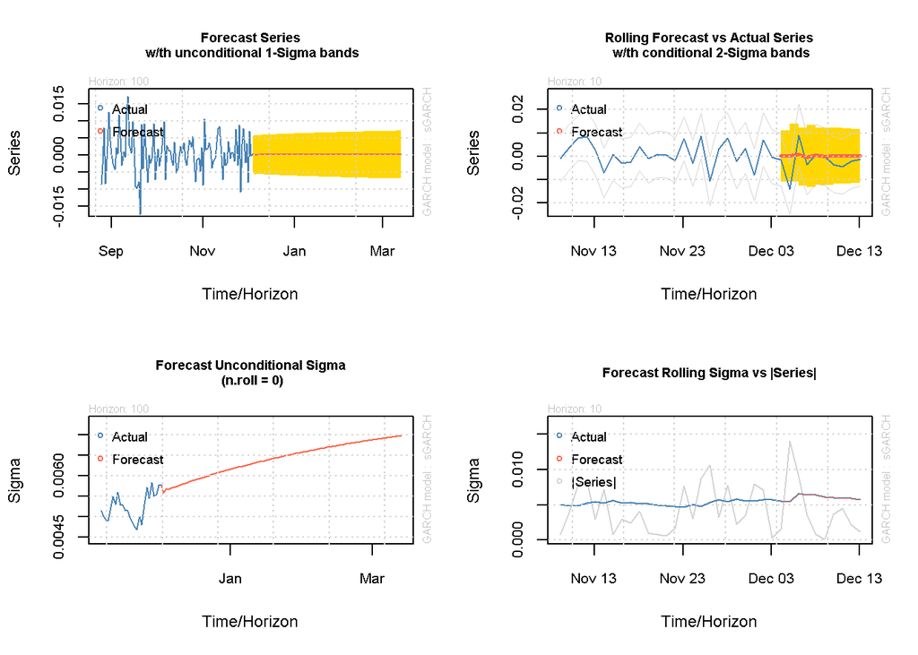

```r
plot(forc, which= "all")
```

##

```r
p.t_1 = 81.074
  R_t <-c(0.005572, 0.005672, 0.005652, 0.005696, 0.005705, 0.005733, 0.005750, 0.005772, 0.005792, 0.005812, 0.005832, 0.005851, 0.005871, 0.005890, 0.005909, 0.005927, 0.005946, 0.005964, 0.005982, 0.006000, 0.006018, 0.006036, 0.006053, 0.006070, 0.006087, 0.006104, 0.006120, 0.006137, 0.006153, 0.006169, 0.006185, 0.006201, 0.006216, 0.006232, 0.006247, 0.006262, 0.006277, 0.006292, 0.006307, 0.006321, 0.006335, 0.006350, 0.006364, 0.006378, 0.006391, 0.006405, 0.006418, 0.006432, 0.006445, 0.006458, 0.006471, 0.006484, 0.006497, 0.006509, 0.006522, 0.006534, 0.006546, 0.006558, 0.006570, 0.006582, 0.006594, 0.006606, 0.006617, 0.006629, 0.006640, 0.006651, 0.006662, 0.006673, 0.006684, 0.006695, 0.006705, 0.006716, 0.006726, 0.006737, 0.006747, 0.006757, 0.006767, 0.006777, 0.006787, 0.006797, 0.006807, 0.006816, 0.006826, 0.006835, 0.006845, 0.006854, 0.006863, 0.006872, 0.006881, 0.006890, 0.006899, 0.006908, 0.006916, 0.006925, 0.006934, 0.006942, 0.006950, 0.006959, 0.006967, 0.006975)
  p_t= 0
  for (i in 1:100){
    p_t =  p.t_1 *((2.71828)^(R_t[i]/100))
    print(p_t)
    p.t_1=p_t
  }
```

```
## [1] 81.07852
## [1] 81.08312
## [1] 81.0877
## [1] 81.09232
## [1] 81.09694
## [1] 81.10159
## [1] 81.10626
## [1] 81.11094
## [1] 81.11564
## [1] 81.12035
## [1] 81.12508
## [1] 81.12983
## [1] 81.13459
## [1] 81.13937
## [1] 81.14417
```

[output cut: 85 more lines]